# ARBRES CART EN CLASSIFICATION

EP - FOUILLE DE DONNEES AVEC R - Bertrand Roudier - ESIEE Paris

#### 1. Introduction

- L’objectif de ce Travail est de vous initier à l’utilisation des arbres en ML à l’aide des packages *rpart* et *rpart.plot*. Bien que les arbres de classification ne soient pas beaucoup utilisés directement, leur compréhension est indispensable car ils sont à la base de très nombreuses méthodes bien plus performantes telles que les forêts aléatoires.
- Les étapes sont les suivantes
  - Description et utilisation de la méthode CART avec R
  - Processus d’élagage
  - Validation croisée avec des critères de complexité (nombre de feuilles après élagage) différents
  - Qualité de l’ajustement en généralisation avec courbe ROC, seuillage et matrice des confusions
- Concernant la qualité de l’ajustement, nous utiliserons la fonction locale que nous avons décrite dans le TD sur la régression logistique multiple.

#### 2. Description de la méthode CART

##### 2.1. Chargement des packages et des données

###### 2.1.1. Packages

```r
rm(list = ls())
LoadPack <- function(Packrequired)
{
  for(i in 1:length(Packrequired))
  {
    if(require(Packrequired[i], character.only = TRUE) == FALSE){install.packages(Packrequired[i])}
    library(Packrequired[i],character.only = TRUE)
  }
  print('Package ... DONE')
}
pack <- c('ggplot2','caret', 'pROC','reshape2', 'kableExtra','rpart','rpart.plot' )
#-> chargement des packages
LoadPack(pack)
```

```
## [1] "Package ... DONE"
```

```r
#-> Chargement des données
df <- read.table('heart.csv', header = T, sep = ',', dec = '.')
```

```r
Valid_ROC <- function(obs, pred, direction = 0, threshold  = NULL, graph = T)
{
  require(pROC)
  require(caret)
  if(!is.factor(obs)){obs <- factor(obs)}
  lev        <- levels(obs)
  data_logit <- data.frame(obs = factor(obs), pred = pred)
  data_roc   <- roc(obs,pred)
  cir        <- ci(data_roc)
  data_spec  <- data.frame( sens    = data_roc$sensitivities ,
                            spec    = data_roc$specificities ,
                            thr     = data_roc$thresholds    ,
                            youden  = data_roc$sensitivities + data_roc$specificities - 1
                           )
  cir <- data.frame(roc = c(cir, youden = max(data_spec$youden) )) ; rownames(cir) <-c('AUC_lower','AUC','AUC_upper','youden')
  #-> si argument nulle alors calcul du seuil par la méthode de Youden
  if (is.null(threshold))
  {
    id       <- which.max(data_spec$youden) ; data_spec[id,] ;
    best_thr <- data_spec[id,3]
  }else{best_thr <- threshold}
  #-> binarisation
  if(direction == 0){dir_name <- lev[1] ; ndir_name <- lev[2] }else{dir_name = lev[2] ; ndir_name <- lev[1]}
  fac_roc    <- rep(dir_name,nrow(data_logit))
  id         <- which(pred >= best_thr) ; fac_roc[id] <- ndir_name ; fac_roc <- factor(fac_roc)
  conf_mat_1 <- confusionMatrix(fac_roc, obs)
  result     <- data.frame(Confusion = c(                 conf_mat_1$overall[1],
                                                          conf_mat_1$overall[3],
                                                          conf_mat_1$overall[4],
                                                          conf_mat_1$byClass[1],
                                                          conf_mat_1$byClass[2],
                                                          conf_mat_1$byClass[3],
                                                          conf_mat_1$byClass[4],
                                                          conf_mat_1$byClass[7],
                                                          Threshold  = best_thr
                                          )
                         )
  all_result <- list( result = result, Confusion = conf_mat_1$table, roc = cir)
  #--> graphique
  if(graph)
    {  data_gr    <- melt(data_spec, id.vars = 'thr')
       gr         <- ggplot(data = data_gr) + geom_line(aes(x = thr, y = value, color = variable )) +
       ylab('Probability') + xlab('threshold') + theme(legend.title = element_blank()) + geom_vline( xintercept = best_thr, color = '#0066CC')
      #--> courbe roc
      plot.roc(data_roc, print.auc=TRUE, print.thres=TRUE,col="#0066CC")
      all_result[['graph']] <- gr
  }
      return( all_result)
}
```

###### 2.1.2. Description des données

- Les maladies cardiovasculaires (MCV) sont la première cause de décès dans le monde, prenant environ 17,9 millions de vies chaque année, ce qui représente 31 % de tous les décès dans le monde. Quatre décès par 5 sont dus à des crises cardiaques et à des accidents vasculaires cérébraux, et un tiers de ces décès surviennent prématurément chez des personnes de moins de 70 ans. L’insuffisance cardiaque est un événement courant causé par les maladies cardiovasculaires et cet ensemble de données contient 11 caractéristiques qui peuvent être utilisées pour prédire une éventuelle maladie cardiaque.
- Les personnes atteintes de maladies cardiovasculaires ou à haut risque cardiovasculaire (en raison de la présence d’un ou plusieurs facteurs de risque tels que l’hypertension, le diabète, l’hyperlipidémie ou une maladie déjà établie) ont besoin d’une détection et d’une prise en charge précoces dans lesquelles un modèle d’apprentissage automatique peut être d’une grande aide.
- Les variables prédictives (Prédicteur)
  - Âge : âge du patient [années]
  - Sexe : sexe du patient [M : Masculin, F : Féminin]
  - ChestPainType : type de douleur thoracique [TA : Angine typique, ATA : Angine atypique, NAP : Douleur non angineuse, ASY : Asymptomatique]
  - BP au repos : pression artérielle au repos [mm Hg]
  - Cholestérol : cholestérol sérique [mm/dl]
  - FastingBS : glycémie à jeun [1 : si FastingBS > 120 mg/dl, 0 : sinon]
  - ECG au repos : résultats de l’électrocardiogramme au repos [Normal : normal, ST : présentant une anomalie de l’onde ST-T (inversions de l’onde T et/ou élévation ou - dépression du segment ST > 0,05 mV), HVG : montrant une hypertrophie ventriculaire gauche probable ou certaine selon les critères d’Estes]
  - MaxHR : fréquence cardiaque maximale atteinte [Valeur numérique entre 60 et 202]
  - ExerciseAngina : angine induite par l’effort [O : Oui, N : Non]
  - Oldpeak : oldpeak = ST [Valeur numérique mesurée en dépression]
  - ST_Slope : la pente du segment ST d’exercice maximal [Haut : ascendant, Plat : plat, Bas : descendant]
- la variable à prédire
  - HeartDisease : classe de sortie [1 : maladie cardiaque, 0 : normal]

Les données sont les suivantes (10 premières lignes)

| Age | Sex | ChestPainType | RestingBP | Cholesterol | FastingBS | RestingECG | MaxHR | ExerciseAngina | Oldpeak | ST_Slope | HeartDisease |
| --- | --- | --- | --- | --- | --- | --- | --- | --- | --- | --- | --- |
| 40 | M | ATA | 140 | 289 | 0 | Normal | 172 | N | 0.0 | Up | 0 |
| 49 | F | NAP | 160 | 180 | 0 | Normal | 156 | N | 1.0 | Flat | 1 |
| 37 | M | ATA | 130 | 283 | 0 | ST | 98 | N | 0.0 | Up | 0 |
| 48 | F | ASY | 138 | 214 | 0 | Normal | 108 | Y | 1.5 | Flat | 1 |
| 54 | M | NAP | 150 | 195 | 0 | Normal | 122 | N | 0.0 | Up | 0 |
| 39 | M | NAP | 120 | 339 | 0 | Normal | 170 | N | 0.0 | Up | 0 |
| 45 | F | ATA | 130 | 237 | 0 | Normal | 170 | N | 0.0 | Up | 0 |
| 54 | M | ATA | 110 | 208 | 0 | Normal | 142 | N | 0.0 | Up | 0 |
| 37 | M | ASY | 140 | 207 | 0 | Normal | 130 | Y | 1.5 | Flat | 1 |
| 48 | F | ATA | 120 | 284 | 0 | Normal | 120 | N | 0.0 | Up | 0 |

#### 3. Description des fonctions rpart.control et rpart

- Le code source la méthode *CART* n’est pas publique. la fonction rpart procède de manière très proche.
- Cette fonction réalise les arbres de décision (en classification ou en régression) **et** un élagage par validation croisée.

##### 3.1. fonction **rpart.control**

- Au préalable de son utilisation, il est nécessaire de réaliser des pré-réglages à l’aide de la fonction *rpart.control*. Les arguments principaux sont les suivants:
  - *minsplit* : Nombre minimum d’observations devant exister dans un noeud pour être diviser
  - *minbucket* : Nombre minimal d’obrevation dans une feuille (terminale)
  - *xval* : nombre de validation croisée
  - *maxdepth* : profondeur de l’arbre
  - *cp* : *équivalent* au coût complexité par défaut cp = 0.01. Si cp = 0, la profondeur de l’arbre sera maximale. Nous concernant, il s’agira du paramètres décisionnel quant aux choix de l’élagage

##### 3.2. fonction **rpart**

- Une fois les pré-réglages effectués, nous pouvons réaliser la classification en validation croisée à l’aide de la fonction *rpart*. les principaus arguments sont les suivants :
  - *formula* : déclaration de la variable à expliquer et des variables explicatives (cf. TP précédents)
  - *data* : dataframe étudié
  - *method* : en classification = **‘class’** et en regrassion = **‘anova’**
  - *parms* : identification de la méthode de division (split) : cette argument est une liste pouvant contenir plusieurs éléments. dans notre cas, cette argument sera *parms = list(split = ‘gini’)*
  - *control* : correspond à la fonction *rpart.control*

##### 3.2. Analyse de l’arbre complet

- Dans un premier temps, on réalise l’analyse sur un arbre complet en incluant toutes les variables du prédicteur
  - nombre de validation croisée = 10
  - minbucket = 1 (“force” la profondeur de l’arbre)
  - cp = 0 : développement de l’arbre entier

```r
#-> génération de la graine pour la validation croisée
set.seed(785123)
options_1 <- rpart.control(xval = 10, cp = 0, minbucket = 1)
cart_1    <- rpart("HeartDisease~.",data = df, parm = list(split = 'gini'), control = options_1)
```

###### 3.2.1 Compléxité

- On peut visualiser l’arbre complet.. qui est “illisible”. Vouloir identifier les noeuds de segmentation des variables n’a aucun sens compte tenu de la profondeur de l’arbre. L’interprétation est impossible

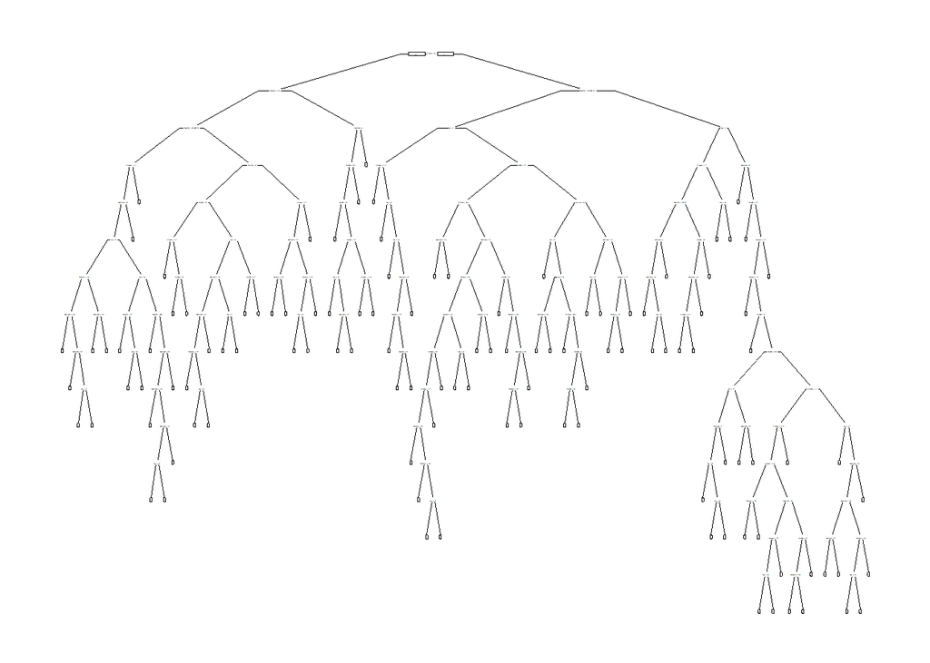

```r
g1 =  prp(cart_1, cex  = 0.05)
```

###### 3.2.2 Qualité de prédiction de l’arbre complet

- Pour estimer la qualité de prédiction sur l’arbre complet, on utilise la fonction *predict*, cette fonction retourne l’affectation sous forme d’une matrice à deux colonnes, chacune correspondant à la probabilité d’affectation à l’une des modalités de la variable à prédire

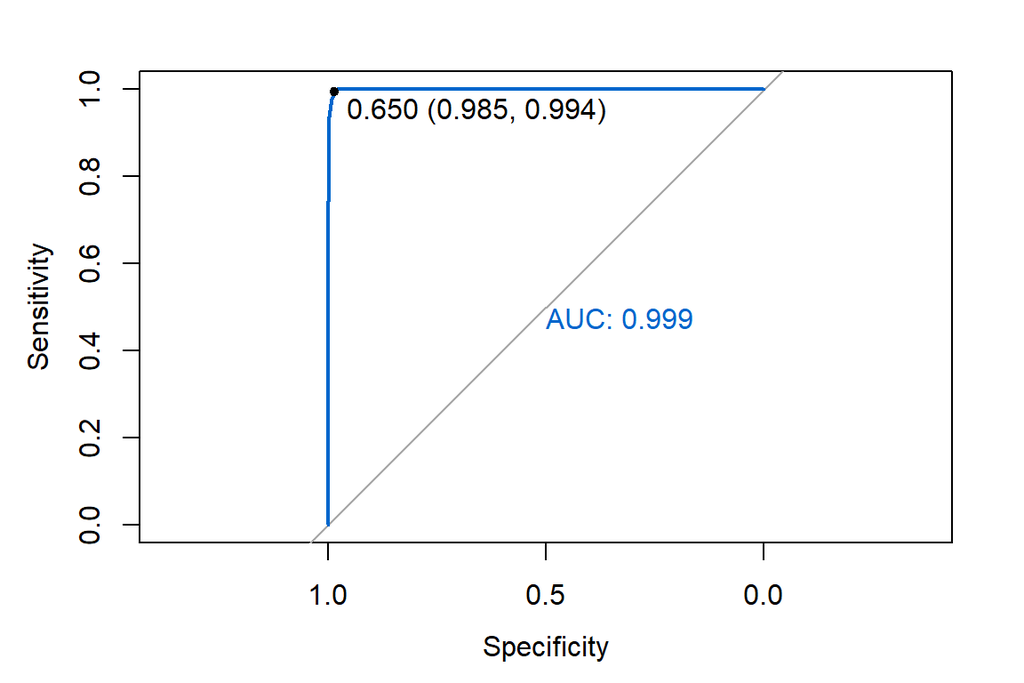

```r
pred_cart_1     <- predict(cart_1, type = 'prob')
result          <- Valid_ROC( as.numeric(df$HeartDisease) - 1, pred_cart_1[,2], graph = T)
```

- Comme on peut s’y attendre, la classification obtenue est excellente. Cependant, elle n’est pas généralisable compte tenu de la profondeur de l’arbre. Nous sommes clairement en surapprentissage.

|  | roc |
| --- | --- |
| AUC_lower | 0.9983284 |
| AUC | 0.9992054 |
| AUC_upper | 1.0000000 |
| youden | 0.9794603 |

- La matrice des confusion au seuil correspondant à l’indice de Youden est :

|  | Confusion |
| --- | --- |
| Accuracy | 0.9901961 |
| AccuracyLower | 0.9814710 |
| AccuracyUpper | 0.9955075 |
| Sensitivity | 0.9853659 |
| Specificity | 0.9940945 |
| Pos Pred Value | 0.9926290 |
| Neg Pred Value | 0.9882583 |
| F1 | 0.9889841 |
| Threshold | 0.6500000 |

#### 4. Elagage

- la fonction *rpart* retourne de nombreux éléments dans une liste. Parmi ces derniers, le premier à analyser est le tableau *cptable*. Ce dernier indique :
  - **CP** : les coûts complexités calculés à partir des différents élagages (seuls les principaux figurent dans la colonnes),
  - **split** : correspond au nombre de divisons par CP
  - **rel err**: nombre de mauvais classements en pourcentage *SANS* validation croisée (réalisation simple de l’arbre)
  - **xerror** : nombre de mauvais classement on pourcentage *AVEC* validation croisée
  - **xstd** : déviation standard pour chaque élagage obtenue par validation croisée

```r
data.frame(cart_1$cptable)  %>% kbl() %>%  kable_styling( position = "center", full_width = FALSE)
```

| CP | nsplit | rel.error | xerror | xstd |
| --- | --- | --- | --- | --- |
| 0.5829268 | 0 | 1.0000000 | 1.0000000 | 0.0367383 |
| 0.0487805 | 1 | 0.4170732 | 0.4170732 | 0.0287709 |
| 0.0182927 | 2 | 0.3682927 | 0.3902439 | 0.0280343 |
| 0.0146341 | 4 | 0.3317073 | 0.4146341 | 0.0287058 |
| 0.0073171 | 6 | 0.3024390 | 0.3926829 | 0.0281032 |
| 0.0060976 | 13 | 0.2512195 | 0.4097561 | 0.0285746 |
| 0.0048780 | 15 | 0.2390244 | 0.4097561 | 0.0285746 |
| 0.0036585 | 21 | 0.2097561 | 0.4317073 | 0.0291535 |
| 0.0032520 | 30 | 0.1756098 | 0.4219512 | 0.0288999 |
| 0.0024390 | 36 | 0.1536585 | 0.4170732 | 0.0287709 |
| 0.0018293 | 57 | 0.1024390 | 0.4146341 | 0.0287058 |
| 0.0016260 | 61 | 0.0951220 | 0.4317073 | 0.0291535 |
| 0.0012195 | 64 | 0.0902439 | 0.4414634 | 0.0294014 |
| 0.0008130 | 102 | 0.0317073 | 0.4804878 | 0.0303386 |
| 0.0000000 | 114 | 0.0219512 | 0.4926829 | 0.0306145 |

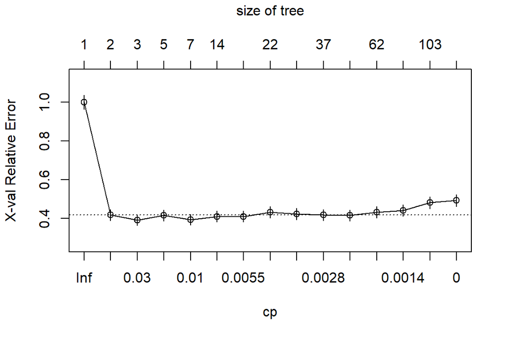

```r
plotcp(cart_1)
```

##### 4.2 Elagage

- L’élagage de l’arbre est réalisée à l’aide de la fonction *prune* en indiquant la valeur du CP choisie (0.0073171):

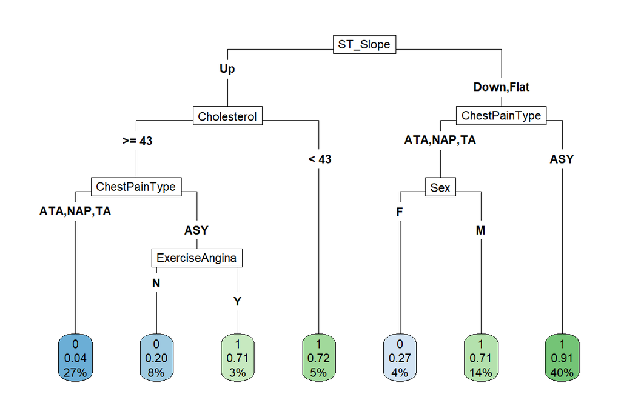

```r
prune_1 = prune(cart_1, cp = 0.0073171)
rpart.plot(prune_1, type = 5)
```

##### 4.3 Qualité de prédiction de l’élagage

- La courbe ROC fournit une AUC de 90% ce qui présage une bonne prédictibilité en généralisation.

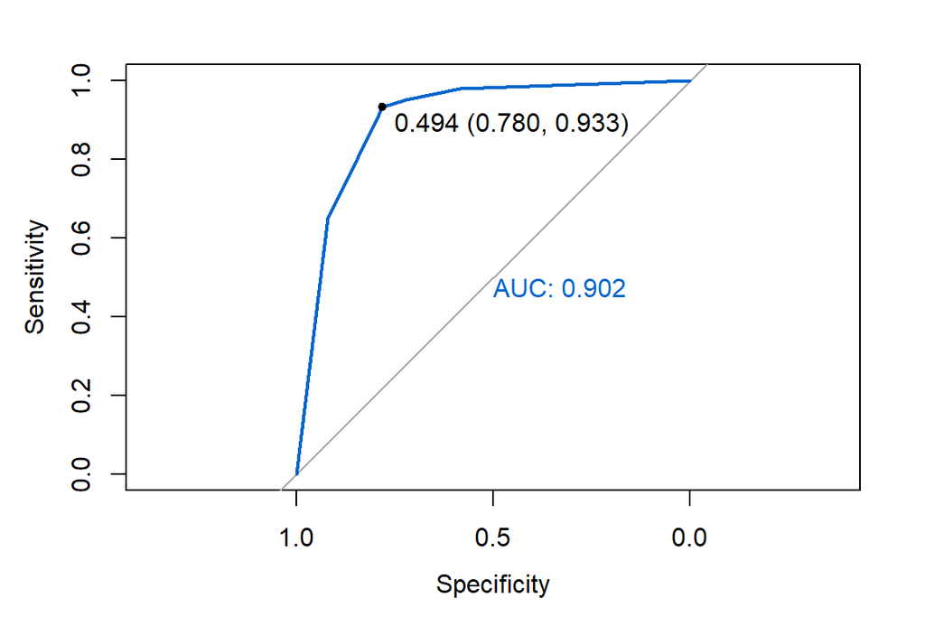

|  | roc |
| --- | --- |
| AUC_lower | 0.8817249 |
| AUC | 0.9022782 |
| AUC_upper | 0.9228315 |
| youden | 0.7135587 |

```r
pred_prune_1     <- predict(prune_1, type = 'prob')
result_prune     <- Valid_ROC( as.numeric(df$HeartDisease) - 1, pred_prune_1[,2], graph = T)
```

- La matrice des confusions au seuil correspondant à l’indice de Youden :

|  | 0 | 1 |
| --- | --- | --- |
| 0 | 320 | 34 |
| 1 | 90 | 474 |

|  | Confusion |
| --- | --- |
| Accuracy | 0.8649237 |
| AccuracyLower | 0.8410956 |
| AccuracyUpper | 0.8863804 |
| Sensitivity | 0.7804878 |
| Specificity | 0.9330709 |
| Pos Pred Value | 0.9039548 |
| Neg Pred Value | 0.8404255 |
| F1 | 0.8376963 |
| Threshold | 0.4935065 |

**Conclusions**

- Aprés Elagage de l’arbre, on constate :
  - que le nombre de variables importantes pour la classification des maladies cardiovasculaires est restreint. Cela permet donc d’éliminer des variables *superflues*.
  - que la profondeur de l’arbre après élagage permet une interprétation des données ( … et uniquement des données fournies .. prudence et parcimonie en Santé).
  - que l’élagage permet une bonne prédiction en généralisation que nous devons cependant étudier et valider.
- Dans un cadre de recherche opérationnelle, il serait impératif :
  - de tester la prédiction à l’aide d’un jeux de données de validation (qui n’a jamais servi ni à l’apprentissage ni au test)
  - de tester la prédiction en sélectionnant différentes profondeurs d’arbres en proximité des règles 0-SE et 1-SE.

#### 5. **TO-DO** - Déploiement - Validation

*rmq* les résultats sont variables (mais convergents) dans la mesure ou ils dépendent de l’échantillonnage

- Table d’élagage

| CP | nsplit | rel error | xerror | xstd |
| --- | --- | --- | --- | --- |
| 0.5784884 | 0 | 1.0000000 | 1.0000000 | 0.0402695 |
| 0.0581395 | 1 | 0.4215116 | 0.4215116 | 0.0315746 |
| 0.0203488 | 2 | 0.3633721 | 0.3982558 | 0.0308845 |
| 0.0159884 | 4 | 0.3226744 | 0.3750000 | 0.0301557 |
| 0.0101744 | 6 | 0.2906977 | 0.3488372 | 0.0292857 |
| 0.0087209 | 8 | 0.2703488 | 0.3575581 | 0.0295818 |
| 0.0072674 | 9 | 0.2616279 | 0.3546512 | 0.0294838 |
| 0.0058140 | 11 | 0.2470930 | 0.3575581 | 0.0295818 |
| 0.0048450 | 16 | 0.2180233 | 0.3662791 | 0.0298718 |
| 0.0038760 | 19 | 0.2034884 | 0.3691860 | 0.0299671 |
| 0.0029070 | 23 | 0.1860465 | 0.3779070 | 0.0302490 |
| 0.0021802 | 54 | 0.0959302 | 0.4156977 | 0.0314056 |
| 0.0019380 | 58 | 0.0872093 | 0.4389535 | 0.0320682 |
| 0.0017442 | 61 | 0.0813953 | 0.4418605 | 0.0321485 |
| 0.0014535 | 66 | 0.0726744 | 0.4680233 | 0.0328479 |
| 0.0009690 | 95 | 0.0232558 | 0.4680233 | 0.0328479 |
| 0.0000000 | 98 | 0.0203488 | 0.4738372 | 0.0329977 |

- Graphique des erreurs (VC) en fonction du CP et des élagages

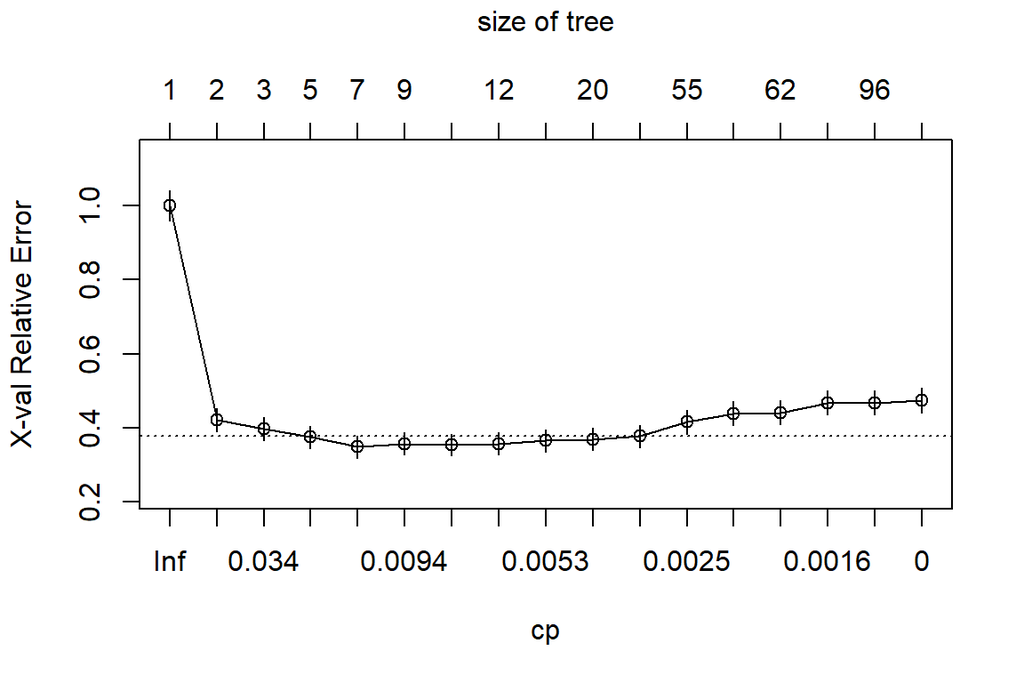

- Arbre élagué

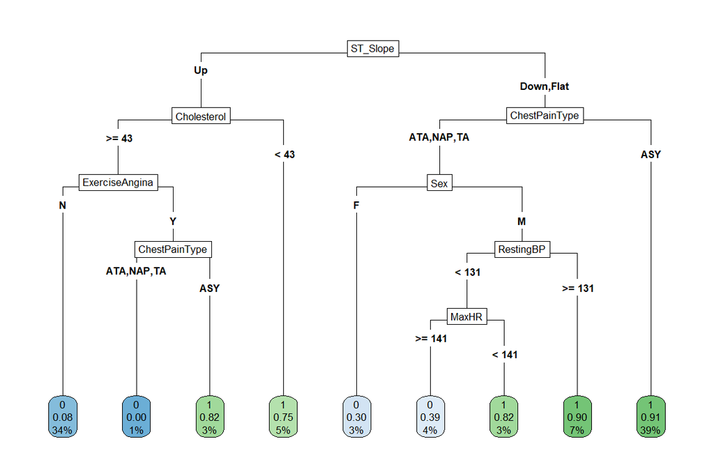

  ***
- Qualité de la prédiction sur les données de déploiement

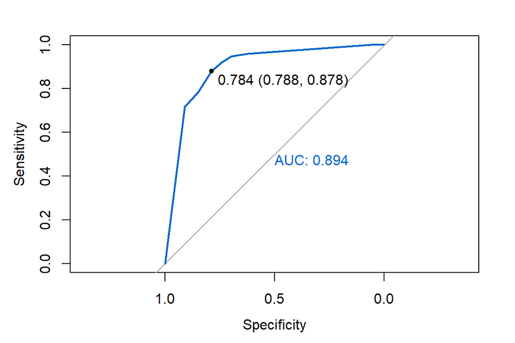

- Résultats courbe ROC

  |  | roc |
  | --- | --- |
  | AUC_lower | 0.8400352 |
  | AUC | 0.8936323 |
  | AUC_upper | 0.9472293 |
  | youden | 0.6662572 |

- Matrice des confusions au seuil déterminé par l’indice de Youden

|  | Confusion |
| --- | --- |
| Accuracy | 0.8357143 |
| AccuracyLower | 0.7637586 |
| AccuracyUpper | 0.8929143 |
| Sensitivity | 0.7878788 |
| Specificity | 0.8783784 |
| Pos Pred Value | 0.8524590 |
| Neg Pred Value | 0.8227848 |
| F1 | 0.8188976 |
| Threshold | 0.7840909 |

|  | 0 | 1 |
| --- | --- | --- |
| 0 | 52 | 9 |
| 1 | 14 | 65 |